# Project: No-show Appointments Data Analysis

- Introduction
- Data Wrangling
- Exploratory Data Analysis
- Conclusions

## Introduction

> In this project we'll be analysing data associated with the **medical appointments in Brazil** and the focus is on question whether or not patients show up for their appointments. Also, we'll be interested in finding the factors that are important for us to know in order to predict if a patient will show up for their scheduled appointment.

> **About Data**

> This dataset has information from 100k medical appointments in Brazil. A number of characteristics about the patient are included in each row.
> - ‘ScheduledDay’ tells us on what day the patient set up their appointment.
> - ‘Neighborhood’ indicates the location of the hospital.
> - ‘Scholarship’ indicates whether or not the patient is enrolled in Brasilian welfare program Bolsa Família.
> - Be careful about the encoding of the last column: it says ‘No’ if the patient showed up to their appointment, and ‘Yes’ if they did not show up.

```python
#Import required libraries
import numpy as np
import pandas as pd
import matplotlib.pyplot as plt
import seaborn as sns
% matplotlib inline
```

## Data Wrangling

> In this section of the report, we will load the data, check for cleanliness, and then trim and clean the dataset for analysis.

### General Properties

```python
# Load dataset
df = pd.read_csv('noshowappointments-kagglev2-may-2016.csv')
df.head()
```

|  | PatientId | AppointmentID | Gender | ScheduledDay | AppointmentDay | Age | Neighbourhood | Scholarship | Hipertension | Diabetes | Alcoholism | Handcap | SMS_received | No-show |
| --- | --- | --- | --- | --- | --- | --- | --- | --- | --- | --- | --- | --- | --- | --- |
| 0 | 2.987250e+13 | 5642903 | F | 2016-04-29T18:38:08Z | 2016-04-29T00:00:00Z | 62 | JARDIM DA PENHA | 0 | 1 | 0 | 0 | 0 | 0 | No |
| 1 | 5.589978e+14 | 5642503 | M | 2016-04-29T16:08:27Z | 2016-04-29T00:00:00Z | 56 | JARDIM DA PENHA | 0 | 0 | 0 | 0 | 0 | 0 | No |
| 2 | 4.262962e+12 | 5642549 | F | 2016-04-29T16:19:04Z | 2016-04-29T00:00:00Z | 62 | MATA DA PRAIA | 0 | 0 | 0 | 0 | 0 | 0 | No |
| 3 | 8.679512e+11 | 5642828 | F | 2016-04-29T17:29:31Z | 2016-04-29T00:00:00Z | 8 | PONTAL DE CAMBURI | 0 | 0 | 0 | 0 | 0 | 0 | No |
| 4 | 8.841186e+12 | 5642494 | F | 2016-04-29T16:07:23Z | 2016-04-29T00:00:00Z | 56 | JARDIM DA PENHA | 0 | 1 | 1 | 0 | 0 | 0 | No |

```python
# Dimensions of raw dataset
df.shape
```

```
(110527, 14)
```

```python
# To Check which columns have missing values
df.info()
```

```
<class 'pandas.core.frame.DataFrame'>
RangeIndex: 110527 entries, 0 to 110526
Data columns (total 14 columns):
PatientId         110527 non-null float64
AppointmentID     110527 non-null int64
Gender            110527 non-null object
ScheduledDay      110527 non-null object
AppointmentDay    110527 non-null object
Age               110527 non-null int64
Neighbourhood     110527 non-null object
Scholarship       110527 non-null int64
Hipertension      110527 non-null int64
Diabetes          110527 non-null int64
Alcoholism        110527 non-null int64
Handcap           110527 non-null int64
SMS_received      110527 non-null int64
No-show           110527 non-null object
dtypes: float64(1), int64(8), object(5)
memory usage: 11.8+ MB
```

```python
# Descriptive statistics of dataset
df.describe()
```

|  | PatientId | AppointmentID | Age | Scholarship | Hipertension | Diabetes | Alcoholism | Handcap | SMS_received |
| --- | --- | --- | --- | --- | --- | --- | --- | --- | --- |
| count | 1.105270e+05 | 1.105270e+05 | 110527.000000 | 110527.000000 | 110527.000000 | 110527.000000 | 110527.000000 | 110527.000000 | 110527.000000 |
| mean | 1.474963e+14 | 5.675305e+06 | 37.088874 | 0.098266 | 0.197246 | 0.071865 | 0.030400 | 0.022248 | 0.321026 |
| std | 2.560949e+14 | 7.129575e+04 | 23.110205 | 0.297675 | 0.397921 | 0.258265 | 0.171686 | 0.161543 | 0.466873 |
| min | 3.921784e+04 | 5.030230e+06 | -1.000000 | 0.000000 | 0.000000 | 0.000000 | 0.000000 | 0.000000 | 0.000000 |
| 25% | 4.172614e+12 | 5.640286e+06 | 18.000000 | 0.000000 | 0.000000 | 0.000000 | 0.000000 | 0.000000 | 0.000000 |
| 50% | 3.173184e+13 | 5.680573e+06 | 37.000000 | 0.000000 | 0.000000 | 0.000000 | 0.000000 | 0.000000 | 0.000000 |
| 75% | 9.439172e+13 | 5.725524e+06 | 55.000000 | 0.000000 | 0.000000 | 0.000000 | 0.000000 | 0.000000 | 1.000000 |
| max | 9.999816e+14 | 5.790484e+06 | 115.000000 | 1.000000 | 1.000000 | 1.000000 | 1.000000 | 4.000000 | 1.000000 |

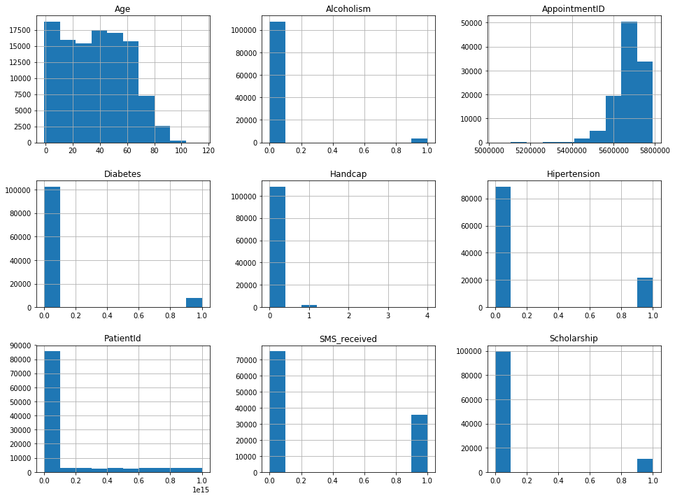

```python
df.hist(figsize=(16,12));
```

> In the **No-show appointments dataset** there are a total of 110527 rows and 14 columns without any missing values in any columns. The descriptive statistics of the dataset shows that the Age column has minimum value of -1 and maximum of 115. From the Age histogram it can be observed that there are only a few patients above age 90. We'll normalize the Age column in the dataset in our further steps to remove these outliers.

> From the histogram of the dataset, we got to know that the values for alcoholism, diabetes, hypertension, sms_received and scholarship are either 0 or 1 which signifies whether the patient is diabetic, alcoholic, and so on.

### Data Sanitization

```python
# Removing typo error, changing to lower case in column header of the dataset
df.rename(columns={'Hipertension':'hypertension', 'Handcap':'handicap', 'No-show':'No_show'}, inplace=True)
df.columns = map(str.lower, df.columns)
df.columns
```

```
Index(['patientid', 'appointmentid', 'gender', 'scheduledday',
       'appointmentday', 'age', 'neighbourhood', 'scholarship', 'hypertension',
       'diabetes', 'alcoholism', 'handicap', 'sms_received', 'no_show'],
      dtype='object')
```

```python
# Removing outliers in Age
df = df[(df['age'] > 0) & (df['age'] <= 90)]
df.describe()
```

|  | patientid | appointmentid | age | scholarship | hypertension | diabetes | alcoholism | handicap | sms_received |
| --- | --- | --- | --- | --- | --- | --- | --- | --- | --- |
| count | 1.066790e+05 | 1.066790e+05 | 106679.000000 | 106679.000000 | 106679.000000 | 106679.000000 | 106679.000000 | 106679.000000 | 106679.000000 |
| mean | 1.472908e+14 | 5.675451e+06 | 38.156797 | 0.101323 | 0.202448 | 0.074157 | 0.031496 | 0.022732 | 0.323513 |
| std | 2.558614e+14 | 7.126018e+04 | 22.301118 | 0.301757 | 0.401827 | 0.262028 | 0.174656 | 0.163274 | 0.467819 |
| min | 3.921784e+04 | 5.030230e+06 | 1.000000 | 0.000000 | 0.000000 | 0.000000 | 0.000000 | 0.000000 | 0.000000 |
| 25% | 4.171437e+12 | 5.640478e+06 | 19.000000 | 0.000000 | 0.000000 | 0.000000 | 0.000000 | 0.000000 | 0.000000 |
| 50% | 3.168363e+13 | 5.680735e+06 | 38.000000 | 0.000000 | 0.000000 | 0.000000 | 0.000000 | 0.000000 | 0.000000 |
| 75% | 9.432541e+13 | 5.725650e+06 | 56.000000 | 0.000000 | 0.000000 | 0.000000 | 0.000000 | 0.000000 | 1.000000 |
| max | 9.999816e+14 | 5.790484e+06 | 90.000000 | 1.000000 | 1.000000 | 1.000000 | 1.000000 | 4.000000 | 1.000000 |

```python
# Converting patientid datatype from float to int
df['patientid'] = df['patientid'].astype(int)
```

```python
# Check duplicate records
sum(df.duplicated())
```

```
0
```

```python
# Convert into datetime
df['scheduledday'] = pd.to_datetime(df['scheduledday']).dt.date
df['appointmentday'] = pd.to_datetime(df['appointmentday']).dt.date
```

```python
# Changing the scheduledday and appointmentday columns name to more appropriate names
df.rename(columns={'scheduledday':'scheduled_date','appointmentday':'appointment_date'},inplace=True)
```

```python
# Adding a column to know the day of week on which Appointment was done
df['dayofweek'] = pd.to_datetime(df['appointment_date']).dt.weekday_name
```

```python
# Validating the result
df.head()
```

|  | patientid | appointmentid | gender | scheduled_date | appointment_date | age | neighbourhood | scholarship | hypertension | diabetes | alcoholism | handicap | sms_received | no_show | dayofweek |
| --- | --- | --- | --- | --- | --- | --- | --- | --- | --- | --- | --- | --- | --- | --- | --- |
| 0 | 29872499824296 | 5642903 | F | 2016-04-29 | 2016-04-29 | 62 | JARDIM DA PENHA | 0 | 1 | 0 | 0 | 0 | 0 | No | Friday |
| 1 | 558997776694438 | 5642503 | M | 2016-04-29 | 2016-04-29 | 56 | JARDIM DA PENHA | 0 | 0 | 0 | 0 | 0 | 0 | No | Friday |
| 2 | 4262962299951 | 5642549 | F | 2016-04-29 | 2016-04-29 | 62 | MATA DA PRAIA | 0 | 0 | 0 | 0 | 0 | 0 | No | Friday |
| 3 | 867951213174 | 5642828 | F | 2016-04-29 | 2016-04-29 | 8 | PONTAL DE CAMBURI | 0 | 0 | 0 | 0 | 0 | 0 | No | Friday |
| 4 | 8841186448183 | 5642494 | F | 2016-04-29 | 2016-04-29 | 56 | JARDIM DA PENHA | 0 | 1 | 1 | 0 | 0 | 0 | No | Friday |

### Mapping no_show column to numerical values to ease summation of count and plotting

#### In no*show columns* 'No' *means that the patient showed up for their appointments, and similarly* 'Yes'_ means that the patient didn't show up for their appointments. So, we have changed this value to more appropriate numerical values 1 and 0 where 0 denotes No (showed up for the appointments) and 1 denotes Yes (didn't show up for the appointments.)

```python
# Mapping no_show data column to numerical
df['no_show'].replace({'No':0,'Yes':1},inplace=True)
```

```python
# Waiting duration between scheduled date and actual appointment date provided to patients
df['waiting_duration'] = df['appointment_date'] - df['scheduled_date']
```

```python
df[df['waiting_duration'] < '0 days']
```

|  | patientid | appointmentid | gender | scheduled_date | appointment_date | age | neighbourhood | scholarship | hypertension | diabetes | alcoholism | handicap | sms_received | no_show | dayofweek | waiting_duration |
| --- | --- | --- | --- | --- | --- | --- | --- | --- | --- | --- | --- | --- | --- | --- | --- | --- |
| 27033 | 7839272661752 | 5679978 | M | 2016-05-10 | 2016-05-09 | 38 | RESISTÊNCIA | 0 | 0 | 0 | 0 | 1 | 0 | 1 | Monday | -1 days |
| 55226 | 7896293967868 | 5715660 | F | 2016-05-18 | 2016-05-17 | 19 | SANTO ANTÔNIO | 0 | 0 | 0 | 0 | 1 | 0 | 1 | Tuesday | -1 days |
| 64175 | 24252258389979 | 5664962 | F | 2016-05-05 | 2016-05-04 | 22 | CONSOLAÇÃO | 0 | 0 | 0 | 0 | 0 | 0 | 1 | Wednesday | -1 days |
| 71533 | 998231581612122 | 5686628 | F | 2016-05-11 | 2016-05-05 | 81 | SANTO ANTÔNIO | 0 | 0 | 0 | 0 | 0 | 0 | 1 | Thursday | -6 days |
| 72362 | 3787481966821 | 5655637 | M | 2016-05-04 | 2016-05-03 | 7 | TABUAZEIRO | 0 | 0 | 0 | 0 | 0 | 0 | 1 | Tuesday | -1 days |

#### We saw that there are 5 records in the dataset where the waiting_duration are -1 days and -6 days which indicates that the appointment date was recorded before the scheduled date by the patients which in this case is erraneous. Also, those people didn't show up for their appointments. So, we will remove these 5 data records from our analysis.

```python
df = df[df['appointment_date'] >= df['scheduled_date']]
```

```python
df.head()
```

|  | patientid | appointmentid | gender | scheduled_date | appointment_date | age | neighbourhood | scholarship | hypertension | diabetes | alcoholism | handicap | sms_received | no_show | dayofweek | waiting_duration |
| --- | --- | --- | --- | --- | --- | --- | --- | --- | --- | --- | --- | --- | --- | --- | --- | --- |
| 0 | 29872499824296 | 5642903 | F | 2016-04-29 | 2016-04-29 | 62 | JARDIM DA PENHA | 0 | 1 | 0 | 0 | 0 | 0 | 0 | Friday | 0 days |
| 1 | 558997776694438 | 5642503 | M | 2016-04-29 | 2016-04-29 | 56 | JARDIM DA PENHA | 0 | 0 | 0 | 0 | 0 | 0 | 0 | Friday | 0 days |
| 2 | 4262962299951 | 5642549 | F | 2016-04-29 | 2016-04-29 | 62 | MATA DA PRAIA | 0 | 0 | 0 | 0 | 0 | 0 | 0 | Friday | 0 days |
| 3 | 867951213174 | 5642828 | F | 2016-04-29 | 2016-04-29 | 8 | PONTAL DE CAMBURI | 0 | 0 | 0 | 0 | 0 | 0 | 0 | Friday | 0 days |
| 4 | 8841186448183 | 5642494 | F | 2016-04-29 | 2016-04-29 | 56 | JARDIM DA PENHA | 0 | 1 | 1 | 0 | 0 | 0 | 0 | Friday | 0 days |

```python
df['waiting_duration'] = df['waiting_duration'].dt.days
```

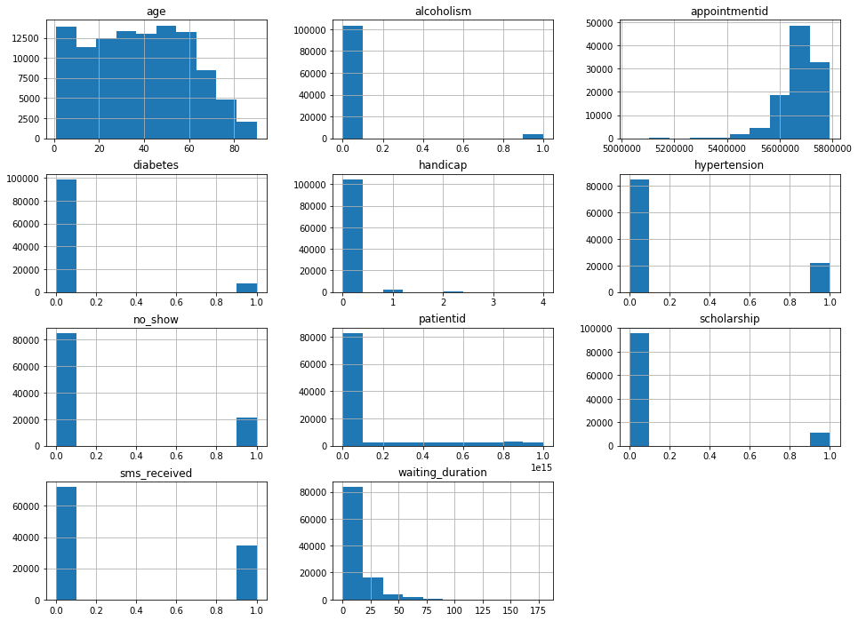

```python
df.hist(figsize=(16,12));
```

## Exploratory Data Analysis

> In this section, we'll be answering multiple questions to support our analysis based on the data provided.

### Q.1 What is percentage of patient that didn't show up for appointment?

```
85061 patients showed up for appointment.
21613 patients didn't up for appointment.
A total of 20.26% of patients who had booked appointment but didn't show up.
```

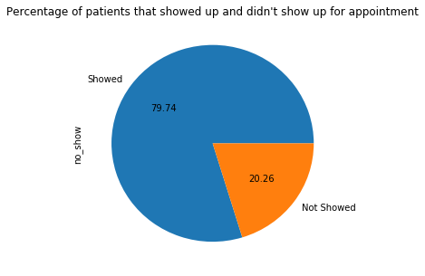

```python
# Chart to show percentage of patient showed up for the appointment or not
showed = df.no_show.value_counts()[0]
print("{} patients showed up for appointment.".format(showed))
not_showed = df.no_show.value_counts()[1]
print("{} patients didn't up for appointment.".format(not_showed))
total = showed+not_showed
print("A total of {:0.2f}% of patients who had booked appointment but didn't show up.".format(not_showed/total*100))
plt.figure(figsize=(5,5))
df.no_show.value_counts().plot(title="Percentage of patients that showed up and didn't show up for appointment", labels=['Showed', 'Not Showed'], autopct='%.2f', kind='pie');
```

### Q.2 What is the ratio of categorical characteristics of the dataset and the no_show characteristic?

> In order to answer this question we will find the ratio against each categorical characteristics. Firstly, we will begin with:
> - **Gender**

```python
# Function to count values
def var_value_counts(var,index1,index2):
    total = df[var].value_counts().sum()
    cat1 = df[var].value_counts()[index1]
    cat2 = df[var].value_counts()[index2]
    return total,cat1,cat2
```

```python
def plot_chart(var,head1,lab1,head2,lab2):
    fig, axes = plt.subplots(1, 2)
    plt.subplots_adjust(left=0.125, bottom=0.1, right=1.9, top=0.9, wspace=1, hspace=1)

    no_show = df.groupby(var)['no_show'].value_counts()
    print("\n{}\n".format(no_show))

    df[var].value_counts().plot(kind='pie', title=head1, autopct="%.2f", labels=lab1, ax=axes[0]);
    grouped_no_show = df.groupby(var)['no_show'].value_counts()
    grouped_no_show.plot(kind='pie', title=head2, autopct="%.2f", labels=lab2, ax=axes[1]);
```

```
Out of 106674 patients, 36779 are male patients and 69895 are female patients.


gender  no_show
F       0          55672
        1          14223
M       0          29389
        1           7390
Name: no_show, dtype: int64
```

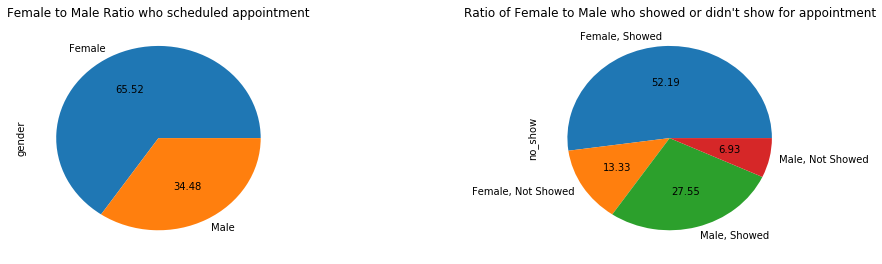

```python
# Chart to show ratio of Male to Female along with who showed up after appointment.
total, male, female = var_value_counts('gender','M','F')
print("Out of {} patients, {} are male patients and {} are female patients.\n".format(total,male,female))

head1 = "Female to Male Ratio who scheduled appointment"
head2 = "Ratio of Female to Male who showed or didn't show for appointment"
lab1 = ['Female', 'Male']
lab2 = ['Female, Showed', 'Female, Not Showed', 'Male, Showed', 'Male, Not Showed']
plot_chart('gender',head1,lab1,head2,lab2)
```

> From the above pie chart, it can be seen clearly that in the given dataset of 100K records, 65.52% patients are female while 34.48% patients are male. Gender donot have an overall impact on the dataset as the distribution is skewed towards women. Also, the females who didn't show up are approximately doubled (13.33%) in comparision to males (6.93%) who didn't show up.

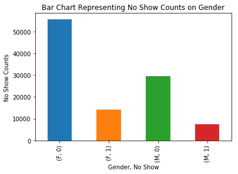

```python
ax = df.groupby('gender')['no_show'].value_counts().plot(kind='bar',y="No Show Count");
ax.set_title('Bar Chart Representing No Show Counts on Gender')
ax.set_ylabel('No Show Counts');
ax.set_xlabel('Gender, No Show');
```

> - **Scholarship**

```
Out of 106674 patients, 10809 have scholarship i.e. they are enrolled in the Brasilian welfare program Bolsa Família while 95865 donot have any scholarship.

scholarship  no_show
0            0          76823
             1          19042
1            0           8238
             1           2571
Name: no_show, dtype: int64
```

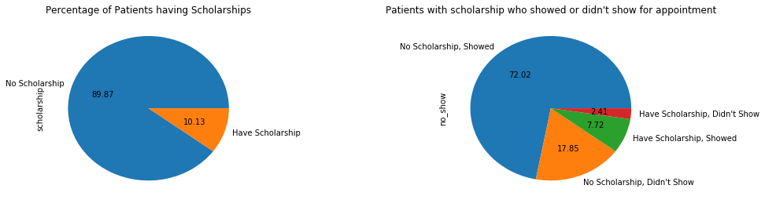

```python
# Patients having scholarships
total_patients, have_scholarship, no_scholarship = var_value_counts('scholarship',1,0)
print("Out of {} patients, {} have scholarship i.e. they are enrolled in the Brasilian welfare program Bolsa Família while {} donot have any scholarship.".format(total_patients,have_scholarship,no_scholarship))

head1 = "Percentage of Patients having Scholarships"
head2 = "Patients with scholarship who showed or didn't show for appointment"
lab1 = ['No Scholarship', 'Have Scholarship']
lab2 = ['No Scholarship, Showed', 'No Scholarship, Didn\'t Show', 'Have Scholarship, Showed', 'Have Scholarship, Didn\'t Show']

plot_chart('scholarship',head1,lab1,head2,lab2)
```

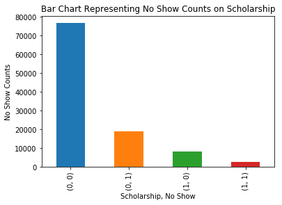

```python
ax = df.groupby('scholarship')['no_show'].value_counts().plot(kind='bar');
ax.set_title('Bar Chart Representing No Show Counts on Scholarship');
ax.set_ylabel('No Show Counts');
ax.set_xlabel('Scholarship, No Show');
```

> - **Hypertension**

```
Out of 106674 patients, 21597 have hypertension while 85077 donot have any hypertension.

hypertension  no_show
0             0          67191
              1          17886
1             0          17870
              1           3727
Name: no_show, dtype: int64
```

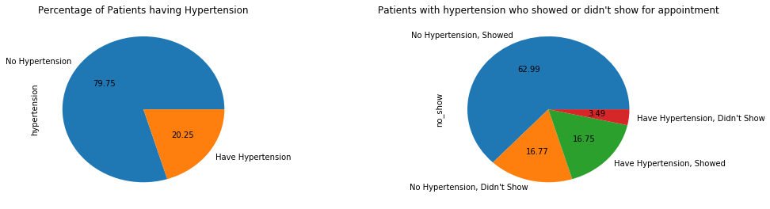

```python
# Patients having hypertension

total_patients, have_hypertension, no_hypertension = var_value_counts('hypertension',1,0)
print("Out of {} patients, {} have hypertension while {} donot have any hypertension.".format(total_patients,have_hypertension,no_hypertension))

head1 = "Percentage of Patients having Hypertension"
head2 = "Patients with hypertension who showed or didn't show for appointment"
lab1 = ['No Hypertension', 'Have Hypertension']
lab2 = ['No Hypertension, Showed', 'No Hypertension, Didn\'t Show', 'Have Hypertension, Showed', 'Have Hypertension, Didn\'t Show']

plot_chart('hypertension',head1,lab1,head2,lab2)
```

> 20.25% patients have hypertension and out of those only 3.49% didn't show up for appointment. Again, hypertension cannot be taken in consideration for patients not showing up after appointment due to small percentage share.

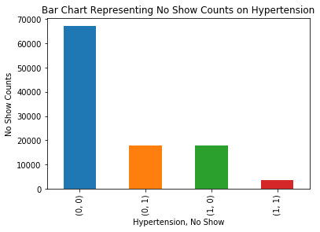

```python
ax = df.groupby('hypertension')['no_show'].value_counts().plot(kind='bar');
ax.set_title('Bar Chart Representing No Show Counts on Hypertension');
ax.set_ylabel('No Show Counts');
ax.set_xlabel('Hypertension, No Show');
```

> - **Alcoholism**

```
Out of 106674 patients, 3360 have alcoholism while 103314 donot have any alcoholism.

alcoholism  no_show
0           0          82378
            1          20936
1           0           2683
            1            677
Name: no_show, dtype: int64
```

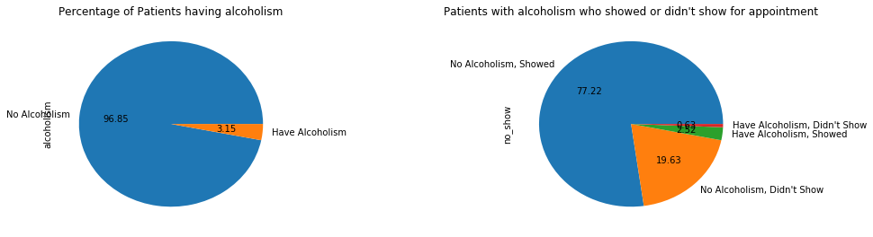

```python
# Patients having Alcoholism

total_patients, have_alcoholism, no_alcoholism = var_value_counts('alcoholism',1,0)
print("Out of {} patients, {} have alcoholism while {} donot have any alcoholism.".format(total_patients,have_alcoholism,no_alcoholism))

head1 = "Percentage of Patients having alcoholism"
head2 = "Patients with alcoholism who showed or didn't show for appointment"
lab1 = ['No Alcoholism', 'Have Alcoholism']
lab2 = ['No Alcoholism, Showed', 'No Alcoholism, Didn\'t Show', 'Have Alcoholism, Showed', 'Have Alcoholism, Didn\'t Show']

plot_chart('alcoholism',head1,lab1,head2,lab2)
```

> Only 3.15% patients have alcoholism who booked appointment and only 0.63% didn't show up for the appointment.

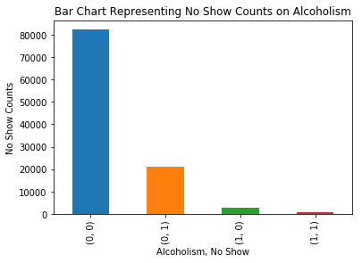

```python
ax = df.groupby('alcoholism')['no_show'].value_counts().plot(kind='bar');
ax.set_title('Bar Chart Representing No Show Counts on Alcoholism');
ax.set_ylabel('No Show Counts');
ax.set_xlabel('Alcoholism, No Show');
```

> - **Diabetes**

```
Out of 106674 patients, 7911 have diabetes while 98763 donot have any diabetes.

diabetes  no_show
0         0          78574
          1          20189
1         0           6487
          1           1424
Name: no_show, dtype: int64
```

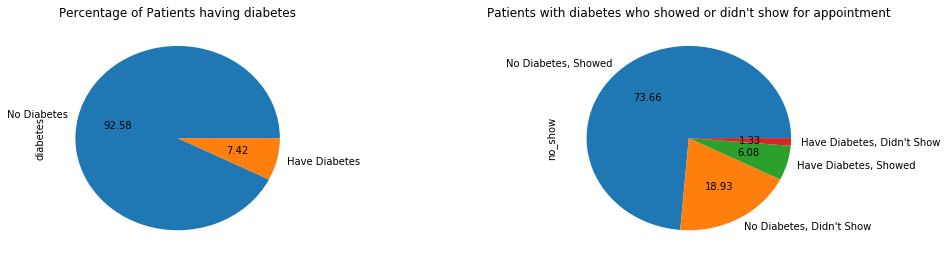

```python
# Patients having Diabetes

total_patients, have_diabetes, no_diabetes = var_value_counts('diabetes',1,0)
print("Out of {} patients, {} have diabetes while {} donot have any diabetes.".format(total_patients,have_diabetes,no_diabetes))

head1 = "Percentage of Patients having diabetes"
head2 = "Patients with diabetes who showed or didn't show for appointment"
lab1 = ['No Diabetes', 'Have Diabetes']
lab2 = ['No Diabetes, Showed', 'No Diabetes, Didn\'t Show', 'Have Diabetes, Showed', 'Have Diabetes, Didn\'t Show']

plot_chart('diabetes',head1,lab1,head2,lab2)
```

> 7.42% patients have diabetes who have scheduled appointments but out of those 7.42%, only 1.33% didn't show up for appointment.

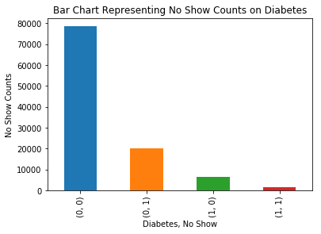

```python
ax = df.groupby('diabetes')['no_show'].value_counts().plot(kind='bar');
ax.set_title('Bar Chart Representing No Show Counts on Diabetes');
ax.set_ylabel('No Show Counts');
ax.set_xlabel('Diabetes, No Show');
```

#### The categorical characterstics of the dataset:

- Gender
- Scholarship
- Hypertension
- Alcoholism
- Diabetes #### doesn't show any influence over no_show characterstic of the dataset. This is due to small percentage share of patients who doesn't show up for appointments. Taking the small percentage share into consideration for analysis will result in biasness.

### Q.3 Do patients who received SMS likely to show up for the appointment?

```
Out of 106674 patients, 34512 have received sms while 72162 donot receive sms.

sms_received  no_show
0             0          60102
              1          12060
1             0          24959
              1           9553
Name: no_show, dtype: int64
```

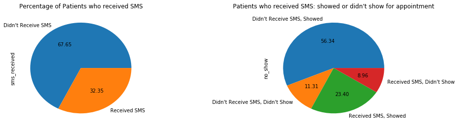

```python
# Patients who received SMS

total_patients, received, not_received = var_value_counts('sms_received',1,0)
print("Out of {} patients, {} have received sms while {} donot receive sms.".format(total_patients,received,not_received))

head1 = "Percentage of Patients who received SMS"
head2 = "Patients who received SMS: showed or didn't show for appointment"
lab1 = ['Didn\'t Receive SMS', 'Received SMS']
lab2 = ['Didn\'t Receive SMS, Showed', 'Didn\'t Receive SMS, Didn\'t Show', 'Received SMS, Showed', 'Received SMS, Didn\'t Show']

plot_chart('sms_received',head1,lab1,head2,lab2)
```

### Q.4 Do age of patients matters who show up to the appointment?

```python
# Create Age Intervals
bins = [0, 5, 10, 15, 20, 25, 30, 35, 40, 45, 50, 55, 60, 65, 70, 75, 80, 85, 90]
df['age_intervals'] = pd.cut(df['age'],bins)
df.head()
```

|  | patientid | appointmentid | gender | scheduled_date | appointment_date | age | neighbourhood | scholarship | hypertension | diabetes | alcoholism | handicap | sms_received | no_show | dayofweek | waiting_duration | age_intervals |
| --- | --- | --- | --- | --- | --- | --- | --- | --- | --- | --- | --- | --- | --- | --- | --- | --- | --- |
| 0 | 29872499824296 | 5642903 | F | 2016-04-29 | 2016-04-29 | 62 | JARDIM DA PENHA | 0 | 1 | 0 | 0 | 0 | 0 | 0 | Friday | 0 | (60, 65] |
| 1 | 558997776694438 | 5642503 | M | 2016-04-29 | 2016-04-29 | 56 | JARDIM DA PENHA | 0 | 0 | 0 | 0 | 0 | 0 | 0 | Friday | 0 | (55, 60] |
| 2 | 4262962299951 | 5642549 | F | 2016-04-29 | 2016-04-29 | 62 | MATA DA PRAIA | 0 | 0 | 0 | 0 | 0 | 0 | 0 | Friday | 0 | (60, 65] |
| 3 | 867951213174 | 5642828 | F | 2016-04-29 | 2016-04-29 | 8 | PONTAL DE CAMBURI | 0 | 0 | 0 | 0 | 0 | 0 | 0 | Friday | 0 | (5, 10] |
| 4 | 8841186448183 | 5642494 | F | 2016-04-29 | 2016-04-29 | 56 | JARDIM DA PENHA | 0 | 1 | 1 | 0 | 0 | 0 | 0 | Friday | 0 | (55, 60] |

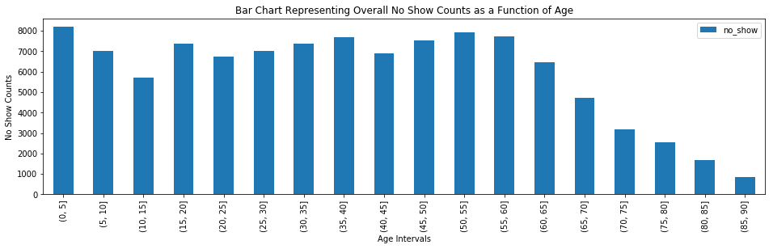

```python
df_gp_ns = df[['age_intervals', 'no_show']].groupby('age_intervals').count()
ax = df_gp_ns.plot(kind='bar', figsize=(16,4));
ax.set_title('Bar Chart Representing Overall No Show Counts as a Function of Age');
ax.set_ylabel('No Show Counts');
ax.set_xlabel('Age Intervals');
```

```python
df_gp_ns.describe()
```

|  | no_show |
| --- | --- |
| count | 18.000000 |
| mean | 5926.333333 |
| std | 2309.880644 |
| min | 852.000000 |
| 25% | 4975.750000 |
| 50% | 6959.500000 |
| 75% | 7483.250000 |
| max | 8192.000000 |

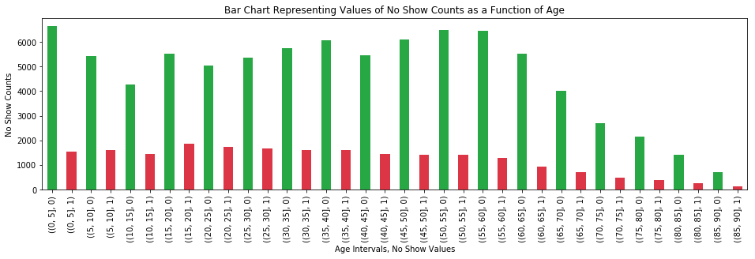

```python
# Plotting bar chart to show no_show counts as a function of age
colors = ['#28a745','#dc3545']*18
df_gp = df.groupby(['age_intervals', 'no_show']).size()
ax = df_gp.plot(kind='bar', figsize=(16,4), title="No Show Values Count as a Function of Age", color=colors);
ax.set_title('Bar Chart Representing Values of No Show Counts as a Function of Age');
ax.set_ylabel('No Show Counts');
ax.set_xlabel('Age Intervals, No Show Values');
```

```python
df_gp.describe()
```

```
count      36.000000
mean     2963.166667
std      2222.526458
min       133.000000
25%      1416.000000
50%      1696.500000
75%      5421.750000
max      6646.000000
dtype: float64
```

> From the above bar charts and thier statistical data, paitents in the age group of (0,5] have the highest shown up to the appointments having value of 6646 out of 8192. That amounts to 81.12% of patients in that age group. If we look at the trend, it declines and then increases in the age group of (15,20]. Upto till the age group of (55,60], the show up shows an increasing trend, declinnig a bit in the age group of (40,45].

### Q.5 What factors are important for us to know in order to predict if a patient will show up for their scheduled appointment?

> In order to answer the above question, we will analyse the following characterstics of the dataset:
> - Neighbourhood
> - Difference Between Scheduled Date & Appointment Date
> - Day of Week
> - **Neighbourhood**

```python
# Grouping no_show on the basis of neighbourhood and taking the top 25 neighbourhood
df_nh = df[['no_show','neighbourhood']].groupby('neighbourhood').count().nlargest(25,columns="no_show")
```

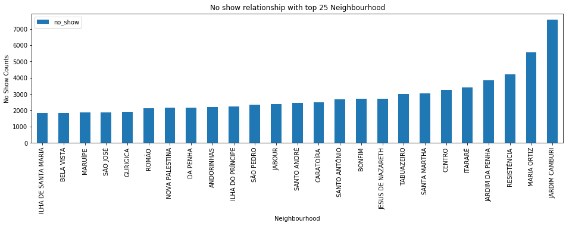

```python
chart_title="No show relationship with top 25 Neighbourhood"
ax = df_nh.sort_values('no_show', ascending=True).plot(kind='bar', figsize=(16,4), title=chart_title);
ax.set_ylabel('No Show Counts');
ax.set_xlabel('Neighbourhood');
```

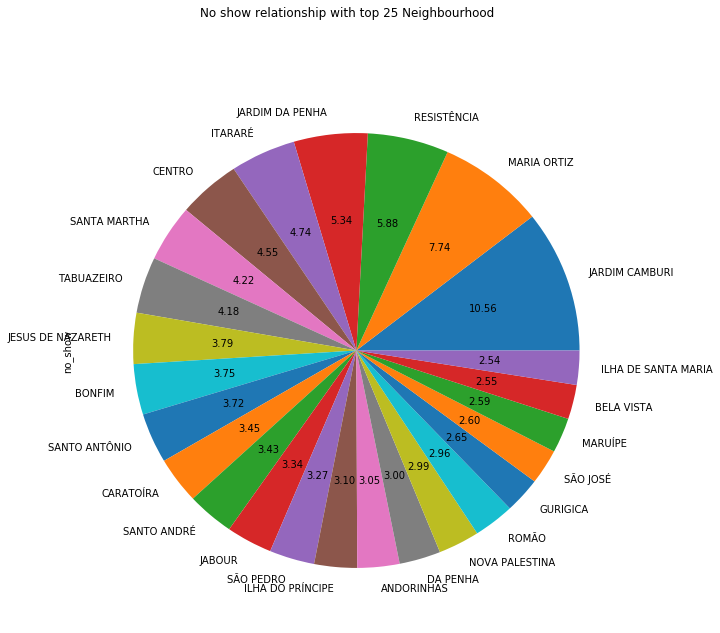

```python
df_nh.plot(kind='pie', figsize=(10,10), title=chart_title, subplots=True, autopct='%.2f', legend=False);
```

```python
# Waiting duration shows the difference between the scheduled date and appointment date in terms of number of days
df_wait = df[['waiting_duration','no_show']].groupby('waiting_duration').count()
```

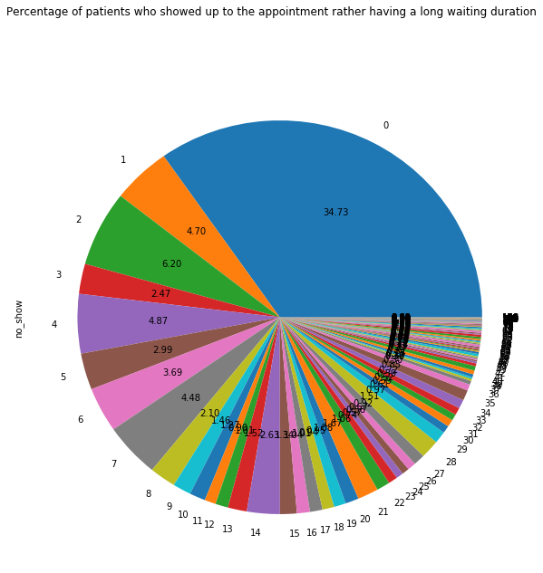

```python
# Percentage of patients who showed up to the appointment rather having a long waiting duration
wait_title = "Percentage of patients who showed up to the appointment rather having a long waiting duration"
df_wait.plot(kind='pie', title=wait_title, autopct="%.2f", subplots=True, legend=False, figsize=(10,10));
```

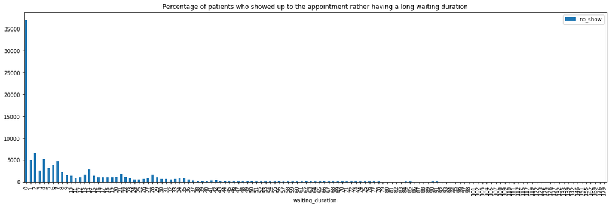

```python
df_wait.plot(kind='bar', title=wait_title, figsize=(20,6));
ax.set_ylabel('No Show Counts');
ax.set_xlabel('Waiting Duration');
```

> From the above charts, we can speculate that there's a huge number of appointments scheduled when the appointment was given on the same day. The maximum number of days is **179 days** when the appointment was given. Since, the waiting duration contains rows that is more than 100 days, we will limit our analysis to only 30 days. Also, after 30 days the number of appointments has reduced significantly.

```python
# Limiting waiting duration to 30 Days only
df_waitingDuration = df.drop(df.index[df.waiting_duration > 30])
```

```python
# Grouping waiting duration with no show column
wait_nsvalue = df_waitingDuration.groupby(['waiting_duration', 'no_show']).size()
wait_ns = df_waitingDuration[['no_show','waiting_duration']].groupby('waiting_duration').count().sort_values('no_show', ascending=False)
```

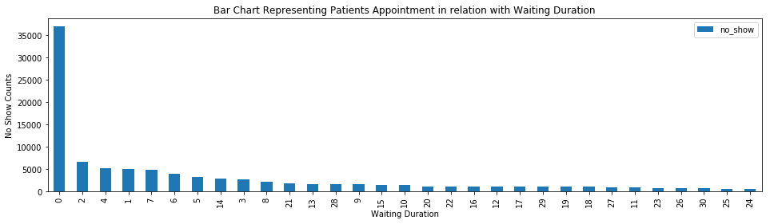

```python
# Plotting pie chart
ax = wait_ns.plot(kind='bar', figsize=(16,4), title="Bar Chart Representing Patients Appointment in relation with Waiting Duration");
ax.set_ylabel('No Show Counts');
ax.set_xlabel('Waiting Duration');
```

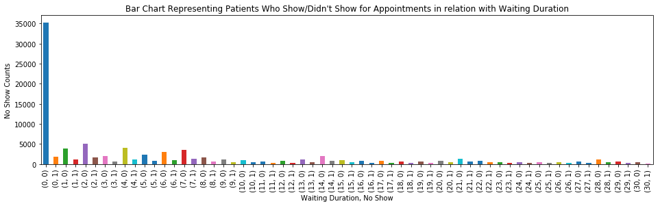

```python
ax = wait_nsvalue.plot(kind='bar', figsize=(16,4), title="Bar Chart Representing Patients Who Show/Didn't Show for Appointments in relation with Waiting Duration");
ax.set_ylabel('No Show Counts');
ax.set_xlabel('Waiting Duration, No Show');
```

> The difference of scheduled date and appointment date i.e., the waiting duration serves as an important factor for patients not showing up. The longer the waiting duration, the lesser is the appointment.
> - **Day of Week**

```python
# Day of Week No Show Count
df_dayofweek = df[['dayofweek','no_show']].groupby('dayofweek').count()
```

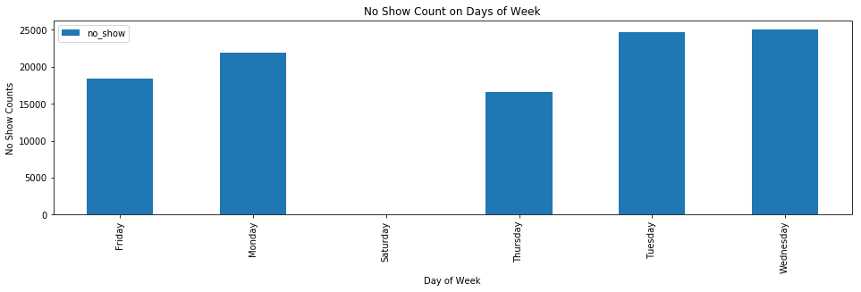

```python
ax = df_dayofweek.plot(kind='bar', title="No Show Count on Days of Week", figsize=(16,4));
ax.set_ylabel('No Show Counts');
ax.set_xlabel('Day of Week');
```

```
dayofweek  no_show
Friday     0          14481
           1           3929
Monday     0          17348
           1           4509
Saturday   0             30
           1              9
Thursday   0          13368
           1           3232
Tuesday    0          19739
           1           5000
Wednesday  0          20095
           1           4934
dtype: int64
```

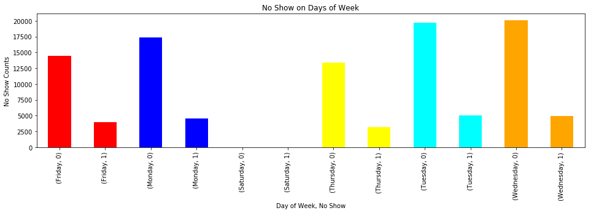

```python
df_dw = df.groupby(['dayofweek', 'no_show']).size()
print(df_dw)
ax = df_dw.plot(kind='bar', figsize=(16,4), title="No Show on Days of Week", color=['red','red','blue','blue','green','green','yellow','yellow','cyan','cyan','orange','orange']);
ax.set_ylabel('No Show Counts');
ax.set_xlabel('Day of Week, No Show');
```

> From the above charts, it can be speculated that no appointments were scheduled on Sunday. On Saturday, only a fraction of patients have scheduled appointments. The maximum appointments were done on Wednesday and Tuesday. Day of the week also plays an important role in predicting whether a person will show up for their scheduled appointment or not.

## Conclusions

### Limitation & Assumption

> - The reason for people who didn't receive SMS reminder is not stated. A large segment of the patients had't received SMS and considering that in analysis will result in biasness.
> - Due to low in numbers, the age of patients greater than 90 were excluded in the analysis.

### References

> - https://translate.google.co.in/translate?hl=en&sl=pt&u=https://pt.wikipedia.org/wiki/Jardim_Camburi&prev=search
> - https://stackoverflow.com/questions/52268909/how-to-pandas-groupby-specific-value-in-a-column/52268983#52268983